# Estimación de parámetros por Máxima Verosimilitud

(Ejemplo Myung, 2003)

### ¿A qué se refiere una función de retención?

Las funciones de retención modelan el hecho de que a las personas les cuesta más trabajo recordar cosas conforme pasa el tiempo. Por lo tanto, este tipo de funciones necesitan ser algún tipo de función decreciente en función del tiempo, que prediga la probabilidad de recordar algo correctamente para diferentes puntos en el tiempo. La literatura propone muchas formas funcionales para esto. Dos de las cuales son la ley de poder y la de decaimento exponencial.

Sea $t$ la variable que denota el tiempo que pasa hasta el ensayo de recuerdo. Sean $x,y$ los dos parámetros libres.

El modelo de función de poder es

$$\hat{p} = x t^{-y}$$

mientras que la función de retención exponencial es

$$\hat{p} = x e^{-yt}$$

### El objetivo de optimizar

Queremos obtener los valores para los parámetros libres $x$ y $y$. Por supuesto necesitamos encontrarlos para cada modelo de manera separada. La pregunta entonces es: dado que existen datos de retención en diferentes puntos en el tiempo - ¿qué valores parametrales $x^*,y^*$ proporcionan la probabilidad de retención predicha más cercana a los datos reales? el uso de la estrella ($^*$) en la notación, comúnmente se usa para denotar los valores que mejor ajustan a la predicciones de los datos.

> Según Myung, “Cercanía con los datos reales” puede ser calculada usando diferentes medidas como la máxima verosimilitud o la suma de errores cuadrados.

### Primer paso: Escribir la función de ajuste

Aquí se presenta una implementación para obtener estos valores usando R.

Primero necesitamos una función para ajustar. La función de ajuste toma como argumentos de entrada los parámetros libres y los datos observados y regresa un número - el valor ajustado.

Vamos a escribir una función que hace dos cosas: Primero, predice las probabilidades de retención y entonces calcula el ajuste entre estas predicciones y las probabilidades de retención observadas.

Queremos una sola función, no muchas. En vez de escribir una función para cada uno de los modelos (uno para el exponencial, otro para la función de poder), haremos esto en una sola función. Simplemente incluimos otro argumento `modelo`dentro de la función indicándole qué función usar. En vez de escribir una función de ajuste para cada una de las medidas de ajuste (una para la log versimilitud, otra para la suma de errores cuadrados), haremos esto en una sola función. Otra vez, incluiremos un argumento `costfn`la cual indicará qué medida de ajuste utilizar.

Nuestra función de ajuste toma como argumentos los dos parámetros libres del modelo (en un vector), las probabilidades de retención observadas, el número de observaciones, qué modelo usar y qué medida de ajuste utilizar.

¿Por qué especifico los parámetros en un vector en vez de especificarlo en dos escalares?, Debido a que cuando optimizamos para encontrar los parámetros de mejor ajuste, la función de optimización requiere que se especifiquen en un solo vector. La función regresará un número, el valor del ajuste.

```r
fitfun = function(f, p, n, t, model, costfn){
    # f : Parámetros libres para las funciones de retención [vector]
    # p: Probabilidades observadas de recuerdo para puntos en el tiempo t [vector]
    # n: Número de personas observadas [escalar]
    # t: Puntos en el tiempo de las observaciones [escalar]
    # model: Cuál modelo usar [string]
    # costfn: Qué medida de ajuste evaluar [string]

    if(length(f) != 2) {
        stop("x debe de ser de tamaño 2") }

    x  = f[1]       # parámetro: tasa de decaimiento
    y  = f[2]       # par: fuerza de la conexión
    n1 = p * n      # datos: número de respuestas "1"
    n2 = (1 - p) * n  # datos: número de respuestas "0"
    e  = 10 ^ -6      # epsilon: sustituiremos con esto p_gorro, si p_gorro = 0.

    # Prediciones
    if(model == "power"){                  # Función de poder
        p_hat = x * t ^ (-y)
    } else if (model == "exponential") {   # Modelo exponencial
        p_hat = x * exp(-y * t)
        }

    # Ajustes
    if(costfn == "SSE"){ # Suma de errores cuadrados
        SSE = sum((p - p_hat)^2)
        SSE
    } else if (costfn == "logLik"){ # Suma de verosimilitud log
        p_hat = ifelse(p_hat == 0, e , ifelse(p_hat == 1, (1 - e), p_hat)) # Asegura 0 < p_hat < 1
        logLik = n1 %*% log(p_hat) + n2 %*% log(1 - p_hat) # Verosimilitud log
        - logLik # scale to get minimization problem
        }
}
```

### Ahora: optimiza esta función de ajuste

Queremos encontrar los valores de $x$ con mejor ajuste. En nuestro caso, queremos minimizar el valor de ajuste sobre x. Por lo tanto, variaremos $x$ mientras mantenemos a todos los demás parámetros constantes. El siguiente código optimiza nuestra función de ajuste dado un conjunto fijo de observaciones (fixed, p, n), un model (modelo fijo) y una medida de ajuste (función de costo fija).

Primero generamos los datos de retención observados.

```r
# Datos observados

pobs = c(.94, .77, .40, .26, .26, .16)    # Probabilidades de retención
nobs = 100                                # Número de personas
tobs = c(1, 3, 6, 9, 12, 18)              # Puntos en el tiempo
```

```r
set.seed(458)

# Iniciar parámetros

init_par = runif(2)          # Valores iniciales para el parámetro

low_par = c(0, 0)           # Límites para circunscribir la optimización
up_par = c(1, 1)
```

Después de eso, la función de optimización hace la optimización por nosotros. En este ejemplo le diremos a la función usar el modelo exponencial como el `modelo`y la verosimilitud log como la función de ajuste. Nota que para que la optimización funcione, los parámetros libres (los parámetros a optimizar) debe ser el primer argumento de la función d eajuste.

```r
library("neldermead")        # Paquete para optimización
set.seed(458)                # Semilla para replicabilidad
optim(
           par = init_par,            # Valores iniciales de los parámetros
           fn = fitfun,               # Función de ajuste
           p = pobs,                  # Argumentos para fit_M()
           n = nobs,                  #  -"-
           t = tobs,                  #  -"-
           model = "exponential",     #  -"-
           costfn = "logLik",         #  -"-
           method = "L-BFGS-B",       # Algoritmo, para mayor información: http://127.0.0.1:23627/library/stats/html/optim.html
           lower = low_par,           # Límites
           upper = up_par
           )
```

```
## $par
## [1] 1.0000000 0.1181419
##
## $value
## [1] 309.4635
##
## $counts
## function gradient
##       27       27
##
## $convergence
## [1] 0
##
## $message
## [1] "CONVERGENCE: REL_REDUCTION_OF_F <= FACTR*EPSMCH"
```

### Optimiza múltiples funciones de ajuste y modelos

El código anterior responde la pregunta de cuáles valores parametrales debemos elegir para el modelo exponencial si optimizáramos la verosimilitud log.

Pero queremos obtener esto para el modelo exponencial y el modelo de poder y para la verosimilitud log y la suma de errores cuadrados. Por lo tanto, repetimos la optimización para todos los modelos y todas las medidas de ajuste. Almacenamos los modelos en un vector que retiene el nombre de los modelos y hace un loop en ese vector. Lo mismo ocurre para las funciones de costo.

```r
library("neldermead")        # Paquete para optimización
set.seed(458)                # Replicabilidad

Models   = c("power","exponential") # Guarda el nombre de los modelos
Costfuns = c("logLik","SSE")        # Guarda el nombre de las funciones de costo

for (i_c in 1:length(Costfuns)) {
    for (i_m in 1:length(Models)){

        # Los resultados se almacenan en Xstar
         Xstar = optim(
              par = init_par,            # Valores parametrales iniciales
              fn = fitfun,               # Función de ajuste
              p = pobs,                  # Argumentos para fit_M()
              n = nobs,                  #  -"-
              t = tobs,                  #  -"-
              model = Models[i_m],     #  -"-
              costfn = Costfuns[i_c],         #  -"-
              method = "L-BFGS-B",       # ALgoritmo, para mayor información: http://127.0.0.1:23627/library/stats/html/optim.html
              lower = low_par,           # Límites
              upper = up_par
              )
        }
}
```

Además, nos gustaría los resultados en una tabla. por lo que creamos un data frame en R para guardar los resultados.

```r
library("neldermead")        #for optimization
set.seed(457)                #replicability

Models   = c("power","exponential") #Holds model names
Costfuns = c("logLik","SSE")        #Holds cost function names

R = data.frame(logLik_power=rep(0,3),logLik_exponential=0,SSE_power=0,SSE_exponential=0,row.names=list("Fit","x","y")) #Initiate results data frame

# Simulate for all Costfuns x Models and write it in corresponding column of R
for (i_c in 1:length(Costfuns)) {
    for (i_m in 1:length(Models)){

        # store results in Xstar
         Xstar = optim(
              par = init_par,            #Parameter starting values
              fn = fitfun,               #fit function
              p = pobs,                  #arguments to fit_M()
              n = nobs,                  #  -"-
              t = tobs,                  #  -"-
              model = Models[i_m],     #  -"-
              costfn = Costfuns[i_c],         #  -"-
              method = "L-BFGS-B",       #algorithm, see see http://127.0.0.1:23627/library/stats/html/optim.html
              lower = low_par,           #bounds
              upper = up_par
              )

           colname = paste(Costfuns[i_c],Models[i_m],sep="_") #target column in R
           R[,colname] = unlist(Xstar[2:1]) #get parameter and assign to target col of R
        }
    }
R[1, ] = round(R[1, ], 2) # Round results data.frame
R[2:3, ] = round(R[2:3, ], 3)
R
```

```
##     logLik_power logLik_exponential SSE_power SSE_exponential
## Fit      315.270            309.460     0.050           0.020
## x          0.953              1.000     1.000           1.000
## y          0.491              0.118     0.504           0.124
```

Los resultados son diferentes de los reportados por Myung (2003), que puede ser debido a la diferencia de algoritmos utilizados.

### Grafica los resultados

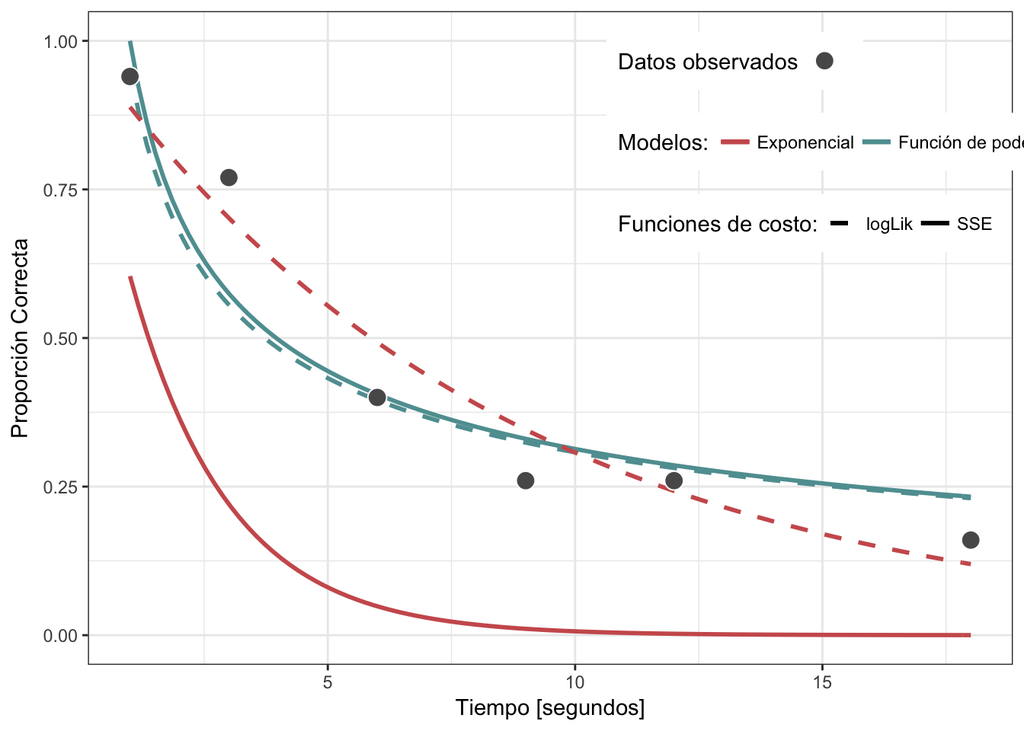

```r
library("ggplot2")              # Paquete para graficar

foo_power = function(w,t) { w[1] * t^(-w[2])}           # Curva de poder
foo_exponential = function(w,t) {w[1] * exp(-w[2] * t)}  # Curva exponencial

PlotDF = data.frame(t_all = 1:6, t = NA,  p = NA)              # DF con todos los valores de x
PlotDF[1:6, "t"] = tobs                         # Substituir con x en DF
PlotDF[1:6, "p"] = pobs

ggplot(PlotDF, aes(x = t_all)) +
    stat_function(fun = foo_power, args = list(w = R[2:3, 1]), size = 1, aes(color = "Función de poder", linetype = "logLik")) +
    stat_function(fun = foo_power, args = list(w = R[2:3, 3]), size = 1, aes(color = "Función de poder", linetype = "SSE")) +
    stat_function(fun = foo_exponential, args = list(w = R[2:3,2]), size=1, aes(color = "Exponencial", linetype = "logLik")) +
    stat_function(fun = foo_exponential, args = list(w = R[2:3, 3]), size = 1, aes(color = "Exponencial", linetype = "SSE")) +
    geom_point(aes(x = t, y = p, shape = " "), size = 4, color = "white", fill = "gray35") +
    theme_bw() +
    scale_linetype_manual("Funciones de costo:", values = c("logLik" = 2,"SSE" = 1,"Data" = NULL)) +
    scale_shape_manual("Datos observados", values=c(" "=21)) +
    scale_color_manual("Modelos:", values = c("Exponencial" = "indian red","Función de poder" = "cadet blue")) +
    scale_x_continuous("Tiempo [segundos]") +
    scale_y_continuous("Proporción Correcta") +
    theme(legend.position = c(0.8, 0.8), legend.direction = "horizontal")
```

**Referencia**

Myung, I. J. (2003). Tutorial on maximum likelihood estimation. Journal of Mathematical Psychology, 47, 90–100. doi:10.1016/S0022-2496(02)00028-7

Código extraído de: http://janajarecki.com/optimization-via-ml-and-sse-for-myung-2003/